# Analysis of Pacific Giant Salamanders in Mack Creek, OR

Richard Viebrock and David Segan

11/27/2019

### **Introduction**

Nestled alongside Oregon’s McKenzie River lies Mack Creek, a forest-dense aquatic area that provides habitat for the Pacific Giant Salamander. The density of forest alongside Mack Creek varies greatly between different forest sections due to historic forest clear-cutting. It is not fully understood whether the clear-cutting of forest has had a significant impact on the Pacific Giant Salamander population in Mack Creek. Fortunately, for the purposes of this report, the Pacific Giant Salamander population along Mack Creek has been monitored in both a clear-cut forest section and a 500-year-old, old-growth forest section since 1993 (Gregory S. V. 2016). Data from this monitoring of Pacific Giant Salamanders includes the specific location of individual observations, overall counts, and individual weights (Gregory S. V. 2016). Here, we analyze this data to provide insight into the the effect that forest clear-cutting has on Pacific Giant Salamander populations in Mack Creek.

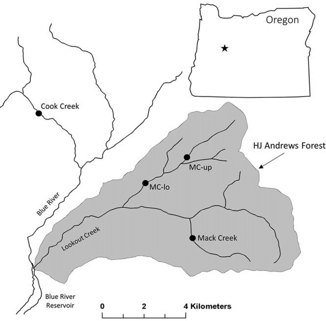

Mack Creek Location. Dana Warren.

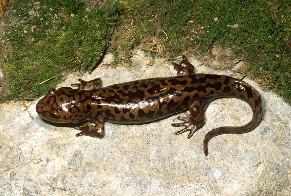

Pacific Giant Salamander. Photo by Karl H. Switak

### **Data and Methods**

Annually collected data on the Pacific giant salamanders from 1993 to 2017 in the old growth section and the previously clear-cut section of the Andrews Experimental Forest was used for the analysis. Among these two groups, counts, weights, and location of salamanders within the Mack Creek channel (pool, cascade, or side-channel) were analyzed using a significance level of 0.05. For more information on collection methods and variables, see [metadata](https://portal.edirepository.org/nis/metadataviewer?packageid=knb-lter-and.4027.12). A chi-squared test was used to determine if there is a significant effect of forest condition (old growth vs clear cut) on where in the channel Pacific Giant Salamander’s are found (Cascades, Side-Channel, and Pool). A two-sample t-test was used to compare the weights of Pacific Giant Salamanders between the two forest sections. Lastly, a one-way ANOVA test, along with Tukey’s HSD and Cohen’s D for post-hoc testing was conducted to compare mean weights across channel locations.

### **Results**

#### **Part A:** Visual Comparison of Salamander Counts

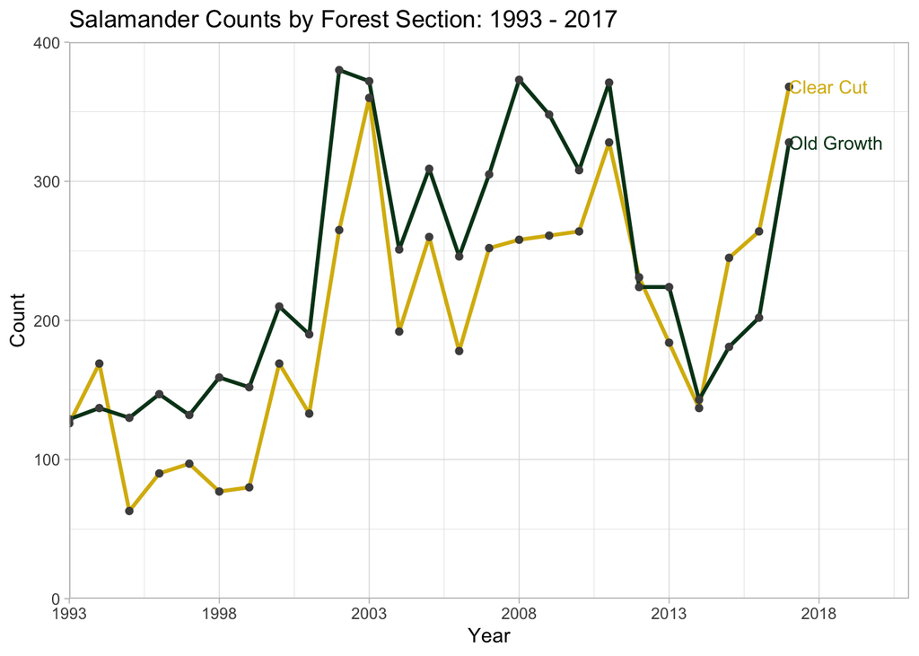

**Figure 1**: *Counts of Pacific Giant Salamander’s compared between clear-cut forest section and old-growth forest section between 1993 and 2017.*

#### **Results B:** 2017 Salamander Counts by Channel Classification

**Table 1:** *2017 Salamander counts by channel classification (pool, cascades, and side-channel) in old-growth and clear-cut sections of Mack Creek. Proportions provide insight into the relationship that exists between forest section and the channel section where Pacific Giant Salamanders were observed.*

| Section | Cascades | Pool | Side Channel |
| --- | --- | --- | --- |
| Clear Cut | 247 (67.1%) | 31 (8.4%) | 90 (24.5%) |
| Old Growth | 201 (62.8%) | 45 (14.1%) | 74 (23.1%) |

#### **Results C:** Analysis of Salamander Counts by Channel Classification

A chi-squared test of independence was conducted to analyze whether there is a significant effect of forest condition on the channel classification where Pacific Giant Salamanders were observed. The analysis shows that, at a 95% confidence level, there is not a significant effect of forest section on where Pacific Giant Salamanders were observed (*p-value*: 0.0626). Despite unequal distribution of salamander counts across forest sections (as seen in Table 1), there is not a statistically significant relationship that exists between forest section and channel classification at the 95% confidence level.

#### **Results D:** Pacific Giant Salamander Weights by Section

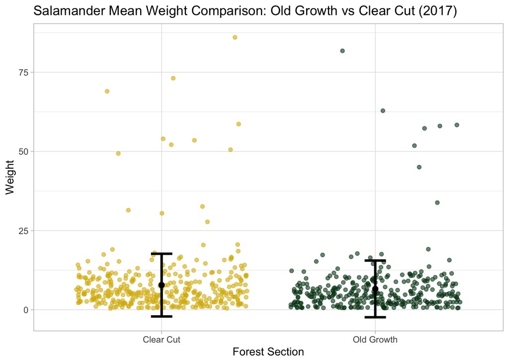

**Figure 2**: *Comparison of weights of Pacific Giant Salamanders observed in clear-cut forest section and old-growth forest section. Mean weight is displayed as black dot with error bars that display one standard deviation from mean. Mean weight of Pacific Giant Salamanders in clear-cut forest sections = 7.78g, and old-growth forest section = 6.58g.*

A Welch’s two sample t-test was conducted to analyze whether there is a significant difference in mean weight of Pacific Giant Salamanders in clear-cut and old-growth forest sections. Test results show that, at a 95% confidence level, there is not a significant difference in the mean weight of Pacific Giant Salamanders between the two forest sections (*p-value:* 0.096). These results reinforce findings in Results A, Results B, and Results C, that indicate that there is no significant effect of forest section on Pacific Giant Salamander populations in Mack Creek.

#### **Results E:** Means Comparison of Salamander Weight by Channel Classification

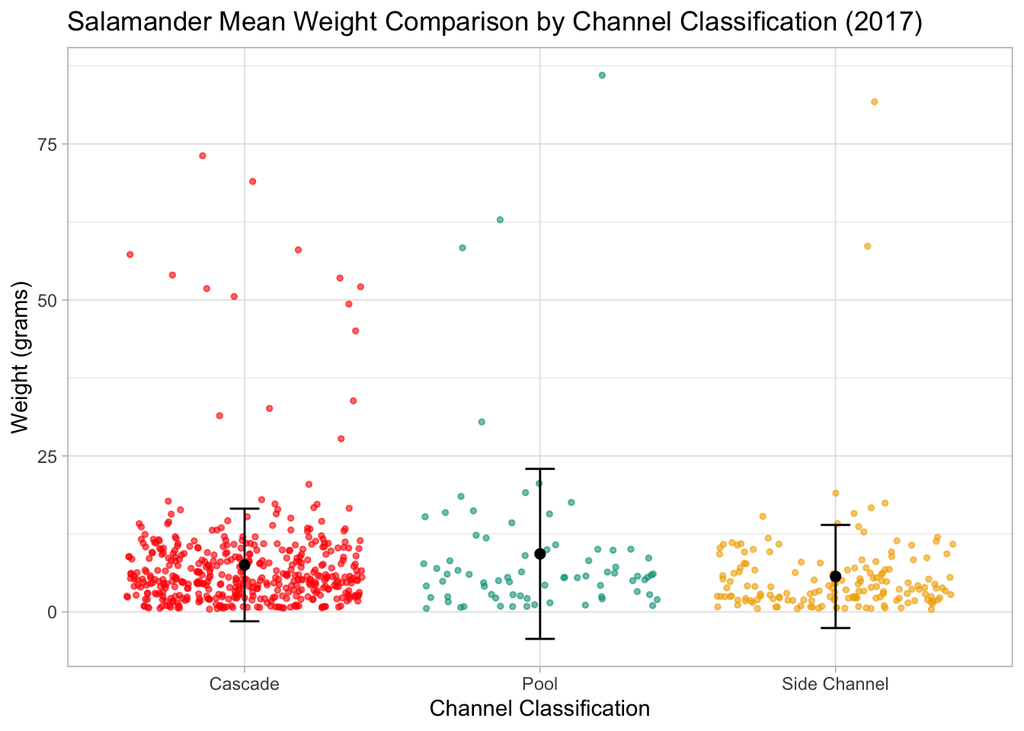

**Figure 3:** *Comparison of weights of Pacific Giant Salamanders observed in Cascades, Pools, or Side Channels.*

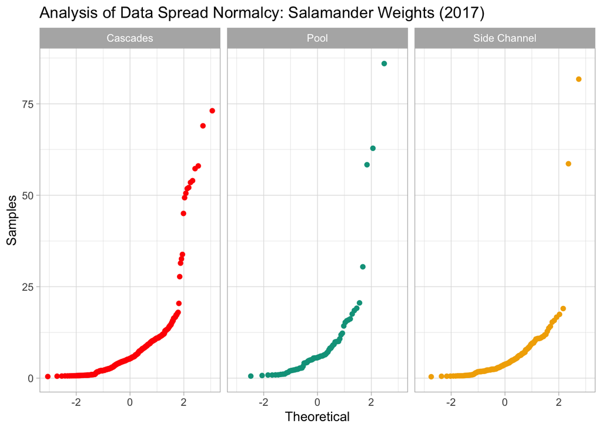

**Figure 4:** *QQ plot to explore normalcy of data spread for weights of Pacific Giant Salamanders observed in different channel classifications (Cascades, Pool, Side-Channel). Actual values of observations were plotted with theoretical normal values and yielded slightly abnormal results.*

#### Levene’s Test for Equal Variance

- Levene’s Test Result: With a p-value of 0.093, this is not significant and we retain the null hypothesis of equal variances.

#### One-way ANOVA & Post-Hoc Testing:

- ANOVA Result: Mean salamander weight (g) differed significantly between the three channel classifications (pool, cascade, side-channel) based on a one-way ANOVA test (F(2, 684) = 4.22, *p-value* = 0.015).
- Tukey’s HSD Result: Pairwise testing reveals that mean weights of Pool salamanders differ significantly from Side Channel salamanders (*p-value* = 0.017), however, means of other pairwise combinations do not differ significantly. Pool salamanders and Cascade salamanders: (*p-value* = 0.286). Side channel salamanders and Cascade salamanders: (*p-value* = 0.084)
- Effect size: Even though a significant difference in means is found between salamanders sampled in pools vs. side-channels, the effect size is small as tested with Cohen’s d: (*d estimate* = 0.35)

#### Analysis of Results

- An Anova test was conducted to compare mean weights of salamanders across channel classifications, regardless of forest section. The results show that at the 95% confidence level, mean salamander weight was only significantly different between salamanders in side channels vs those in pools. While significantly different, the effect size is small, thus leading a conclusion that there is not considerable difference in Pacific Giant Salamander weight across channel classifications.
- Prior to conducting the ANOVA, a QQ plot was created to evaluate normalcy of the weight distributions. The QQ plot revealed that the distributions of weights within each channel type is slightly abnormal. While this raises slight concern for the effectiveness of an ANOVA, it is widely accepted that an ANOVA is robust to violation of the normality assumption. Coupled with a Levene’s test that indicates non-significant difference in variance, the results of the ANOVA test are still valuable. Median weights should be compared for further analysis.

### **References**

Gregory S. V. 2016. Aquatic Vertebrate Population Study in Mack Creek, Andrews Experimental Forest, 1987 to present. Environmental Data Initiative. https://doi.org/10.6073/pasta/5de64af9c11579266ef20da2ff32f702. Dataset accessed 12/01/2019